# Using OLS Regression to Predict Median House Values in Philadelphia

Zhanchao Yang, Haoyu Zhu, Kavana Raju

2025-03-02

# Introduction

Philadelphia has experienced significant demographic and economic transformations over recent decades, leading to notable implications for its urban housing market. These shifts have resulted in variations in median house values, which serve not only as a reflection of the city’s economic health but also as a proxy for broader social and spatial dynamics. Increasing median house values may indicate an influx of higher-income residents or early stages of gentrification, whereas declining values can be symptomatic of disinvestment and economic decline. Given these dynamics, accurately forecasting median house values is vital for urban planners and policymakers who are tasked with promoting sustainable and equitable urban development.

**This study investigates the determinants of housing values in Philadelphia by focusing on four critical neighborhood characteristics: educational attainment, vacancy rates, the proportion of single-family homes, and poverty levels.** These factors are closely related to housing market trends and provide insights into the socioeconomic status of neighborhoods. Educational attainment is closely linked to local economic prosperity. Individuals with higher educational attainment typically earn higher incomes and contribute more robustly to local economies. Consequently, a higher concentration of individuals with advanced educational backgrounds tends to increase demand for quality housing in affluent neighborhoods, thereby driving up housing prices and values. Conversely, high poverty rates signal economic distress, as many residents cannot afford luxury housing, and as a result, the housing values in these neighborhoods are likely to be lower.

High vacancy rates are frequently linked to declining neighborhoods, as vacant properties undermine community vitality, weaken crime prevention efforts, and diminish the overall health of commercial districts. Consequently, areas with a high concentration of vacant housing units tend to exhibit lower median housing values. In addition, although single-family homes are generally valued for their privacy and comfort, their common occurrence in suburban settings is often associated with limited accessibility to urban amenities and inadequate infrastructure, which may ultimately suppress their market values.

In this study, we utilize **ordinary least squares (OLS) regression** to analyze the relationship between these socioeconomic factors and median house values in Philadelphia. By examining these relationships, we aim to identify critical predictors of median housing values throughout Philadelphia and offer insights for decision-makers and community initiatives.

# Methods

## Data Cleaning

To predict median house values in Philadelphia, we obtained the original dataset from the United States Census data, which represents census block groups from the year 2000 and initially contained 1,816 observations. The key variables included:

- **POLY_ID** – Census Block Group ID
- **MEDHVAL** – Median value of all owner-occupied housing units
- **PCBACHMORE** – Proportion of residents in the block group with at least a bachelor’s degree
- **PCTVACANT** – Proportion of housing units that are vacant
- **PCTSINGLES** – Percentage of housing units that are detached single-family houses
- **NBELPOV100** – Number of households with incomes below 100% of the poverty level
- **MEDHHINC** – Median household income

For modeling purposes, we refined the dataset using the following criteria:

1. Retained block groups with a population greater than 40
2. Included only block groups that contained housing units
3. Excluded records where the median house value was below $10,000

In additon, we removed one specific block group in North Philadelphia that exhibited inconsistencies, as it had an unusually high median house value (over $800,000) despite a very low median household income (less than $8,000).

After these cleaning steps, the final dataset contained 1,720 observations.

## Exploratory Data Anaylsis

### Summary Statistics

We will first examine the summary statistics **mean** and **standard deviation (SD)** of key variables in the dataset. These include the dependent variable `MEDHVAL` (**Median House Value**), and the predictors `NBELPOV100` (**Households Living in Poverty**), `PCTBACHMOR` (**% of Individuals with Bachelor’s Degrees or Higher**), `PCTVACANT`(**% of Vacant Houses**), and `PCTSINGLES`(**% of Single House Units**).

The **mean** ($\bar{X}$) represents the average value of a variable and is calculated as follows:

$$\bar{X} = \frac{1}{n} \sum_{i=1}^{n} X_i$$

where:

- $X_i$ represents each individual observation
- $n$ is the total number of observations

The mean provides a single representative value of the dataset. To measure the variability of the data, we use the **standard deviation (SD)**, which quantifies how much the values in a dataset deviate from the mean. The formula for the sample standard deviation ($s$) is:

$$s = \sqrt{\frac{1}{n-1} \sum_{i=1}^{n} \left( X_i - \bar{X} \right)^2}$$

where:

- $X_i$ represents each individual observation
- $\bar{X}$ is the mean of the observations
- $n$ is the total number of observations

A larger standard deviation indicates that the data points are more spread out, while a smaller standard deviation suggests that the data points are more closely clustered around the mean.

### Distributions

We will also examine the histograms and apply logarithmic transformations to key variables to assess whether the transformed variables exhibit a more normal-like distribution.

**Histograms** provide a visual representation of how a variable’s values are distributed, which helps identify whether the data follows a **normal distribution**, is **right-skewed**, or **left-skewed**. Note that linear regression models assume that variables are approximately normally distributed.

- **X-axis:** Represents the values of the variable (e.g., house prices, income levels).
- **Y-axis:** Represents the frequency of observations within each bin.

A **right-skewed** histogram suggests that a small number of observations have significantly higher values compared to the rest. For variables that exhibit **right-skewness**, a **log transformation** can improve normality. Since the **log transformation** is undefined for zero or negative values, we must first check whether any variable contains zero.

- If **no zeros** are present, we apply the standard log transformation:
  $$X' = \log_{10} (X)$$
- If **zeros** are present, we add 1 to the variable before taking the log:
  $$X' = \log_{10} (X + 1)$$
  This ensures that all values remain positive and avoids undefined values.

By comparing the **original histograms** with the **log-transformed histograms**, we will determine whether the transformation improves the suitability of the data for predictive modeling.

### Correlations

We will analyze the **correlations** between the predictors, to detect potential **multicollinearity** before proceeding with regression analysis, as it can distort model interpretations.

Multicollinearity occurs when predictors are highly correlated with one another, which can lead to unstable regression coefficients, inflated standard errors which reduce the statistical significance of predictors, and a higher risk of overfitting because redundant variables do not provide additional information to the model.

The **correlation coefficient** $r$ quantifies the strength and direction of the linear relationship between two variables. It is calculated as:

$$r = \frac{\sum_{i=1}^{n} (x_i - \bar{x})(y_i -
\bar{y})}{\sqrt{\sum_{i=1}^{n} (x_i - \bar{x})^2 \sum_{i=1}^{n} (y_i -
\bar{y})^2}}$$

In a more concise way, this formula can be expressed as:

$$r = \frac{1}{n-1} \sum_{i=1}^{n} \left( \frac{x_i - \bar{x}}{S_x}
\right) \left( \frac{y_i - \bar{y}}{S_y} \right)$$
where:
- $X_i$ and $Y_i$ are individual data points for variables $X$ and $Y$, respectively.
- $\bar{X}$ and $\bar{Y}$ are the **mean values** of $X$ and $Y$.
- The numerator represents the **covariance** between $X$ and $Y$, while the denominator **normalizes** the values.

The correlation coefficient $r$ ranges from **-1 to 1**: A value of +1 indicates a perfect positive linear relationship, while a value of -1 indicates a perfect negative linear relationship. A value of 0 suggests no linear relationship between the variables, meaning changes in one do not influence the other.

## Multiple Regression Analysis

After getting a general sense of the data, we conduct multiple regression analysis to examine the relationship between the dependent variable, **Median House Value** (`MEDHVAL`), and the predictors, **education attainment** (`PCTBACHMOR`), **number of Households Living in Poverty** (`NBELPOV100`), **percentage of Vacant Houses** (`PCTVACANT`), and **percentage of Single-family House Units** (`PCTSINGLES`). Regression analysis is a statistical method to examine the relationship between a dependent variable and one or more predictors. With this type of analysis, researchers can identify the strength and direction of the relationship between variables, make predictions, and assess the significance of predictors. The model also estimates coefficients for each predictor, which represent the expected change in the dependent variable for a one-unit change in the predictor, holding other predictors constant. For this study, the multiple regression model is formulated as follows:

$$\text{LNMEDHVAL} = \beta_0 + \beta_1 \text{PCTVACANT} + \beta_2
\text{PCTSINGLES} + \beta_3 \text{PCTBACHMOR} + \beta_4
\text{log(NBELPOV100)} + \epsilon$$
where **LNMEDHVAL** is the log-transformed median house value, **PCTVACANT** is the proportion of vacant housing units , **PCTSINGLES** is the proportion of the single family housing , **PCTBACHMOR** is the percentage of the residents holding bachelor’s degree or higher, and **log(NBELPOV100)** is the log-transformed number of households living below the poverty line.

$\beta_0$ is the intercept, $\beta_1$, $\beta_2$, $\beta_3$, and $\beta_4$ are the coefficients for each predictor, and $\epsilon$ is the error term. The coefficient $\beta_1$, $\beta_2$, $\beta_3$, $\beta_4$ represent the change in the log-transformed median house value for a one-unit change in the corresponding predictor, holding other predictors constant. The error term $\epsilon$ accounts for the variability in the dependent variable that is not explained by the predictors.

### Regression Assumptions

For the results of the regression analysis to be valid, several key assumptions must be met. These assumptions include **linearity**, **independence of observations**, **homoscedasticity**, **normality of residuals**, **no multicollinearity**, and **no fewer than 10 observations per predictors**.

- **Linearity** assumes that the relationship between the dependent variable and the predictors is linear. To verify this assumption, we made scatter plots of the dependent variable against each predictor. If the relationship appears to be linear, the assumptions was met.
- **Independence of Observations** assumes that the observations are independent of each other. There should be no spatial or temporal or other forms of dependence in the data.
- **Homoscedasticity** assumes that the variance of the residuals $\epsilon$ is constant regardless of the values of each level of the predictors. To check this assumption, we made a scatter plot of the standardized residuals against the predicted values. If the residuals are evenly spread around zero, the assumption was met. Any patterns may indicate the presence of heteroscedasticity.
- **Normality of Residuals** assumes that the residuals are normally distributed. We examined the histogram of the standardized residuals to check if they are approximately normally distributed. If the histogram is bell-shaped, the assumption was met.
- **No Multicollinearity** assumes that the predictors are not highly correlated with each other. We calculated the correlation matrix of the predictors to check for multicollinearity. If the correlation coefficients are is not greater than 0.8 or less than -0.8, the assumption was met.
- **No Fewer than 10 Observations per Predictor** assumes that there are at least 10 observations for each predictor in the model. Since there are over 1,700 observations in the dataset, this assumption was met.

### Parameter Estimations

After verifing the assumptions of the regression, we start the regression analysis. We estimate the following parameters: - $\beta_0$, which is the intercept - $\beta_1, \dots, \beta_k$, which are the coefficients of each independent variable - $\sigma^2$, the variance of the error terms, which quantifies the variability in the dependent variable that is not explained by the predictors.

The least squares method estimates the coefficients by minimizing **the sum of squared errors (SSE)**, which is the sum of the squared differences between the observed values and the predicted values. The formula for SSE is:

$$\text{SSE} = \sum_{i=1}^{n} (y_i - \hat{y}_i)^2 = \sum_{i=1}^{n} (y_i -
\hat{\beta}_0 - \hat{\beta}_1 x_{i1} - \dots - \hat{\beta}_k x_{ik})^2$$
where $y_i$ is the actual or observed value, $\hat{y}_i$ is the predicted value, $\hat{\beta}_0, \dots, \hat{\beta}_k$ are the estimated coefficients, and $x_{i1}, \dots, x_{ik}$ are the predictor values for the $i$-th observation.

With the Error Sum of Squares (SSE) calculated, we can estimate the variance of the error terms $\sigma^2$ using the formula:

$$\sigma^2 = \frac{\text{SSE}}{n - (k+1)}$$
where $n$ is the number of observations and $k$ is the number of predictors in the model.

### Model Evaluation

We evaluated the model’s fitness using **the coefficient of determination** $R^2$ and **the adjusted** $R^2$. The coefficient of determination $R^2$ measures the proportion of variance in the dependent variable that is explained by the predictors. The adjusted $R^2$ adjusts the $R^2$ value based on the number of predictors, which help to provide a more accurate measure of model fit for multiple regression, as the increase the number of predictors can artificially inflate the $R^2$ value.

To obtain $R^2$, $SST$ or the total sum of squares, needed to be calculated first. The $SST$ measures the total variance in the dependent variable, given by:
$$SST = \sum_{i=1}^{n} (y_i - \bar{y})^2$$
Where $y_i$ is the observed value, and $\bar{y}$ is the mean of the observed value. Then, the $R^2$ can be obtained by:
$$R^2 = 1 - \frac{SSE}{SST}$$
After that, $R^2$ is adjusted as follows based on the number of observations $n$ and the number of predictors $k$:
$$R^2_{\text{adj}} = 1 - \frac{(1 - R^2)(n - 1)}{n - k - 1}$$

### Hypothesis Testing

In this analysis, several hypothesis tests are conducted to determine the significance of the model and its predictors. The overall significance of the model is assessed using the **F-ratio**. It compares the variance explained by the model to the variance not explained by the model.A higher F-ratio indicates that the model explains a significant amount of variance in the dependent variable compared to the residual variance.

The null hypothesis and alternative hypothesis for the F-ratio are stated as follows:

- The **null hypothesis $H_0$** states that all coefficients are equal to zero, meaning that the predictors do not explain the variance in the dependent variable (median house value). Stated as:

  $$H_0: \beta_1 = \beta_2 = \beta_3 = \beta_4 = 0$$
- The **alternative hypothesis $H_a$** states that at least one coefficient is not equal to zero. In our case, this means that at least one predictor explains the variance in the dependent variable (median house value). Stated as:
  $$H_a: \text{At least one } \beta_i \neq 0$$

We also conduct a **t-test** to determine the significance of each individual predictor in the model:

- The **null hypothesis $H_{0i}$** states that the coefficient for the predictor i is equal to zero, meaning that the predictor does not explain the variance in the dependent variable (median house value). Stated as:

  $$H_{0i}: \beta_i = 0$$
- The **alternative hypothesis $H_{ai}$** states that the coefficient for the predictor i is not equal to zero, meaning that the predictor explains the variance in the dependent variable (median house value). Stated as:

  $$H_{ai}: \beta_i \neq 0$$

## Additional Analysis

### Stepwise Regression

In addition to the multiple regression analysis, we conduct stepwise regression analysis to identify the most significant predictors of median house values in Philadelphia. Stepwise regression is a method that automatically selects the best subset of predictors for the model. **It involves adding or removing predictors based on their statistical significance (P-value) and the AIC (Akaike Information Criterion).** The stepwise regression analysis will help us identify the most important predictors and improve the overall model fits.

However, there are several limitations to stepwise regression. First, the final stepwise regression model is not guaranteed to be optimal in any specific sense. There may be other models that are as good as, or even better than the one selected by stepwise regression, but the procedure only yeilds a single model. Second, the stepwise regression does take into account researchers’ knowledge about the predictors. Important variables may be exclude from the model if they are not included in the initially. Moreover, This method also runs the risk of Type I and Type II errors—meaning it may include unimportant variables or exclude important ones.

### Cross-Validation

To evaluate the performance of the regression model, we conduct **K-fold cross-validation**. Cross-validation is a technique used to evluate the performance of the predictive models. In K-fold Cross-Validation, the dataset is randomly divided into K equal-sized folds. The model is trained on K-1 folds and tested on the remaining fold. This process is repeated K times, with each fold serving as the test set exactly once. The average performance across all K folds is then calculated. Cross-validation helps to assess the model’s generalization performance and reduce the risk of overfitting.

**In our analysis, we used K=5, which is a common choice for cross-validation.** The root mean squared error (RMSE) is used to compare the performance of different models. The RMSE measures the difference between the predicted values and the actual values. A lower value of RMSE indicates a better predictive model.

The mean square errors is calculated as follows:
$$\text{MSE} = \frac{1}{n} \sum_{i=1}^{n} (y_i - \hat{y}_i)^2$$
And the root mean square errors (RMSE) is the square root of the mean square errors (MSE):
$$\text{RMSE} = \sqrt{\text{MSE}}$$

## Software and Packages

In this analysis, we utilize the R programming language, a professional statistical software widely used for data analysis and visualization.The following libraries and packages have been employed to conduct the analysis:

- `tidyverse`: A collection of R packages for data manipulation and visualization.
- `sf`: A package for spatial data processing, especially for handling shapefiles.
- `ggplot2`: A popular visualization package for creating high-quality map and charts, part of the `tidyverse` collection.
- `ggcorrplot`: A package designated to visualize correlation matrices using `ggplot2`.
- `patchwork`: A package for combining multiple ggplot2 plots into a single plot.
- `MASS`: A package provides multiple functions and datasets for statistical analysis, including linear models.
- `caret`: A package for creating predictive models and conducting machine learning tasks, used in cross-validation and k-fold analysis.
- `kableExtra`: A package for creating tables with advanced formatting options.

# Results

## Exploratory Results

The table below presents the summary statistics for the key variables, an overview of the central tendency and variability. The dependent variable **median house value** has a **mean** of 66,287.73, indicating that the average median house value by census tract in Philadelphia is approximately 66,287.73 dollar. The **standard deviation** of 60,006.08 dollar suggests that house values exhibit significant variability across census tracts.

For the predictor variables, all have standard deviations close to or greater than the mean, indicating large differences in educational attainment, economic status, housing occupancy, and housing structure composition across Philadelphia’s census block groups.

```r
dependent_var <- "MEDHVAL"

predictors <- c("PCTBACHMOR", "NBELPOV100", "PCTVACANT", "PCTSINGLES")

summary_stats <- data %>%
  dplyr::select(all_of(c(dependent_var, predictors))) %>%
  summarise_all(list(Mean = mean, SD = sd), na.rm = TRUE) %>%
  pivot_longer(cols = everything(), names_to = "Variable", values_to = "Value") %>%
  separate(Variable, into = c("Variable", "Stat"), sep = "_") %>%
  pivot_wider(names_from = Stat, values_from = Value)



summary_stats$Variable <- recode(summary_stats$Variable,
  "MEDHVAL" = "Median House Value",
  "NBELPOV100" = "# Households Living in Poverty",
  "PCTBACHMOR" = "% of Individuals with Bachelor’s Degrees or Higher",
  "PCTVACANT" = "% of Vacant Houses",
  "PCTSINGLES" = "% of Single House Units"
)



summary_stats <- summary_stats %>%
  mutate(
    Mean = round(Mean, 2),
    SD = round(SD, 2)
  )

summary_stats <- summary_stats %>%
  arrange(Variable == "Median House Value")

predictor_rows <- which(summary_stats$Variable != "Median House Value")
dependent_rows <- which(summary_stats$Variable == "Median House Value")

# Determine the start and end rows for each group
start_pred <- min(predictor_rows)
end_pred   <- max(predictor_rows)
start_dep  <- min(dependent_rows)
end_dep    <- max(dependent_rows)

# Create the table using kable and add extra formatting
kable(summary_stats, caption = "Summary Statistics",
      align = c("l", "l", "l"), booktabs = TRUE, escape = FALSE ) %>%
  add_header_above(c(" " = 1, "Statistics" = 2)) %>%
  kable_styling(full_width = FALSE) %>%
  group_rows("Predictors", start_pred, end_pred) %>%
  group_rows("Dependent Variable", start_dep, end_dep)%>%
  kable_styling(bootstrap_options = c("striped", "hover", "condensed"), full_width = TRUE)
```

Summary Statistics

| Variable | Statistics Mean | Statistics SD |
| --- | --- | --- |
| **Predictors** |  |  |
| % of Individuals with Bachelor’s Degrees or Higher | 16.08 | 17.77 |
| # Households Living in Poverty | 189.77 | 164.32 |
| % of Vacant Houses | 11.29 | 9.63 |
| % of Single House Units | 9.23 | 13.25 |
| **Dependent Variable** |  |  |
| Median House Value | 66287.73 | 60006.08 |

### Histogram Distribution

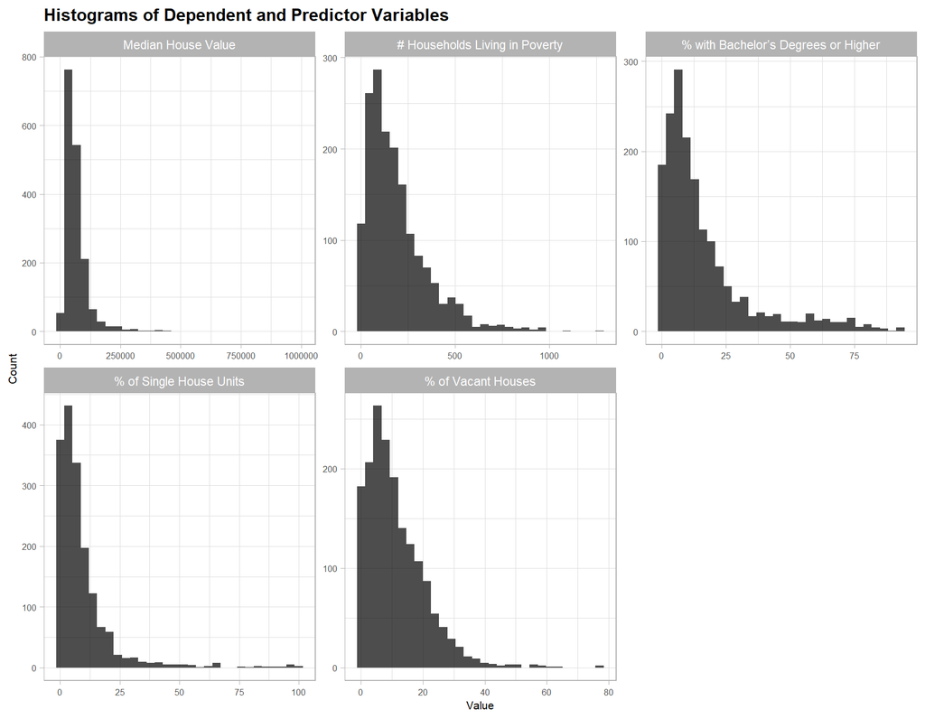

```r
longer_version<- data %>%
  pivot_longer(cols = c("MEDHVAL", "PCTBACHMOR", "NBELPOV100", "PCTVACANT", "PCTSINGLES"),
               names_to = "Variable",
               values_to = "Value")

ggplot(longer_version,aes(x = Value)) +
  geom_histogram(aes(y = ..count..), fill = "black", alpha = 0.7) +
  facet_wrap(~Variable, scales = "free", ncol = 3, labeller = as_labeller(c(
    "MEDHVAL" = "Median House Value",
    "PCTBACHMOR" = "% with Bachelor’s Degrees or Higher",
    "NBELPOV100" = "# Households Living in Poverty",
    "PCTVACANT" = "% of Vacant Houses",
    "PCTSINGLES" = "% of Single House Units"
  ))) +
  labs(x = "Value", y = "Count", title = "Histograms of Dependent and Predictor Variables") +
  theme_light() +
  theme(plot.subtitle = element_text(size = 9,face = "italic"),
        plot.title = element_text(size = 12, face = "bold"),
        axis.text.x=element_text(size=6),
        axis.text.y=element_text(size=6),
        axis.title=element_text(size=8))
```

```r
data <- data %>%
  mutate(
    LNMEDHVAL = log(MEDHVAL),
    LNPCTBACHMOR = log(1+PCTBACHMOR),
    LNNBELPOV100 = log(1+NBELPOV100),
    LNPCTVACANT = log(1+PCTVACANT),
    LNPCTSINGLES = log(1+PCTSINGLES)
  )
```

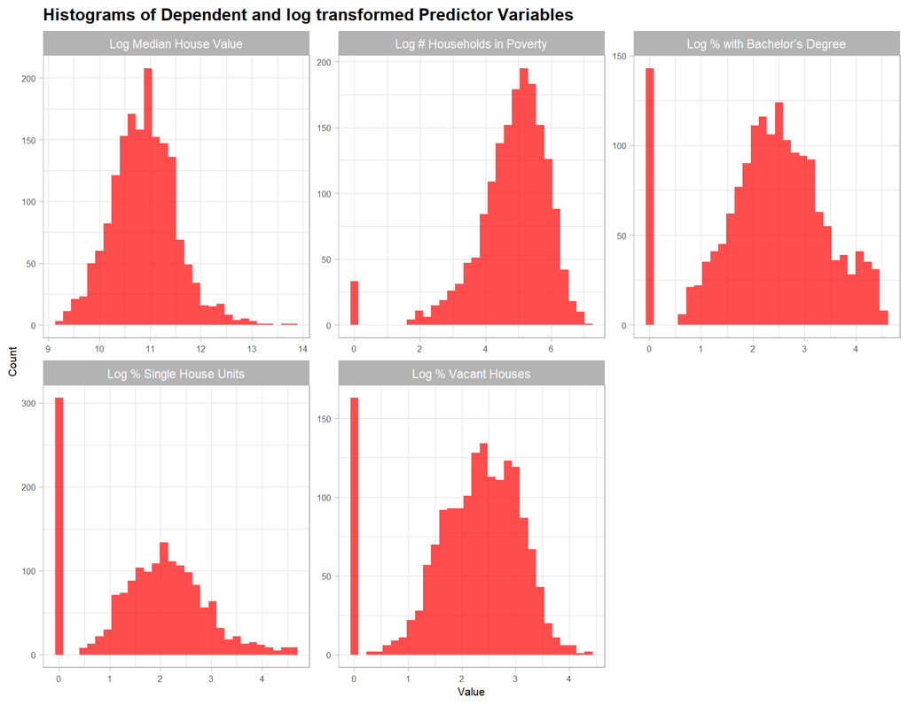

```r
longer_version2 <- data %>%
  pivot_longer(cols = c(LNMEDHVAL, LNPCTBACHMOR ,LNNBELPOV100,LNPCTVACANT, LNPCTSINGLES),
               names_to = "Variable",
               values_to = "Value")

ggplot(longer_version2,aes(x = Value)) +
  geom_histogram(aes(y = ..count..), fill = "red", alpha = 0.7) +
  facet_wrap(~Variable, scales = "free", ncol = 3, labeller = as_labeller(c(
    "LNMEDHVAL" = "Log Median House Value",
    "LNPCTBACHMOR" = "Log % with Bachelor’s Degree",
    "LNNBELPOV100" = "Log # Households in Poverty",
    "LNPCTVACANT" = "Log % Vacant Houses",
    "LNPCTSINGLES" = "Log % Single House Units"
  ))) +
  labs(x = "Value", y = "Count", title = "Histograms of Dependent and log transformed Predictor Variables") +
  theme_light() +
  theme(plot.subtitle = element_text(size = 9,face = "italic"),
        plot.title = element_text(size = 12, face = "bold"),
        axis.text.x=element_text(size=6),
        axis.text.y=element_text(size=6),
        axis.title=element_text(size=8))
```

Other regression assumptions will be assessed separately in the Regression Assumption Checks section later.

### Choropleth Maps

Linearity assumes that the relationship between the dependent variable and the predictors is linear. To examine this relationship, we analyze the spatial distribution of key variables. Certain predictor maps exhibit patterns similar to the dependent variable, suggesting a strong potential relationship.

Below is the choropleth map of the dependent variable, **Log Transformed Median House Value**. It reveals that central city areas and Germantown/Chestnut Hill have higher median house values, while North Philadelphia has lower values.

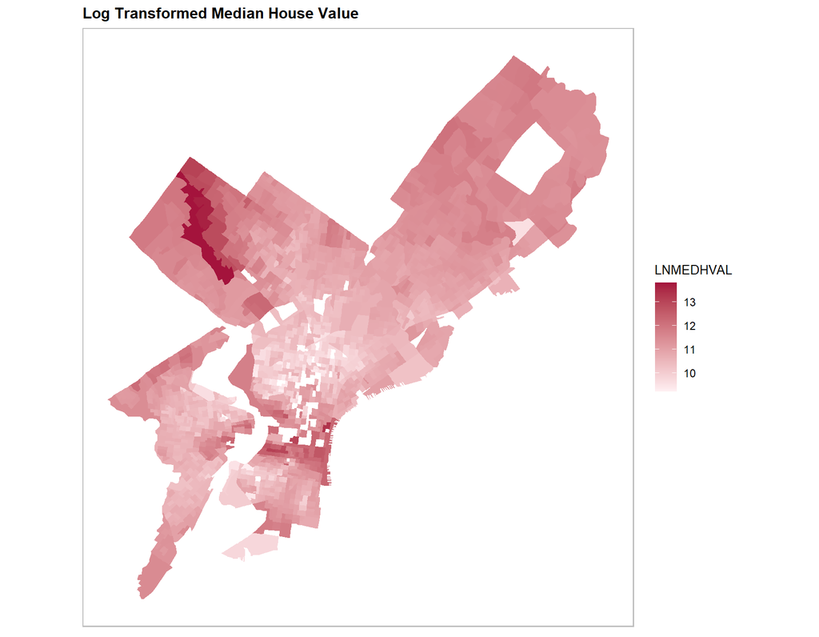

```r
ggplot(shape) +
  geom_sf(aes(fill = LNMEDHVAL), color = "transparent") +
  scale_fill_gradientn(colors = c("#fff0f3", "#a4133c"),
                       name = "LNMEDHVAL",
                       na.value = "transparent") +
  theme(legend.text = element_text(size = 9),
        legend.title = element_text(size = 10),
        axis.text.x = element_blank(),
        axis.ticks.x = element_blank(),
        axis.text.y = element_blank(),
        axis.ticks.y = element_blank(),
        plot.subtitle = element_text(size = 9, face = "italic"),
        plot.title = element_text(size = 12, face = "bold"),
        panel.background = element_blank(),
        panel.border = element_rect(colour = "grey", fill = NA, size = 0.8)) +
  labs(title = "Log Transformed Median House Value")
```

To understand the spatial relationship between the dependent variable and predictors, we present four key predictor maps below as well.

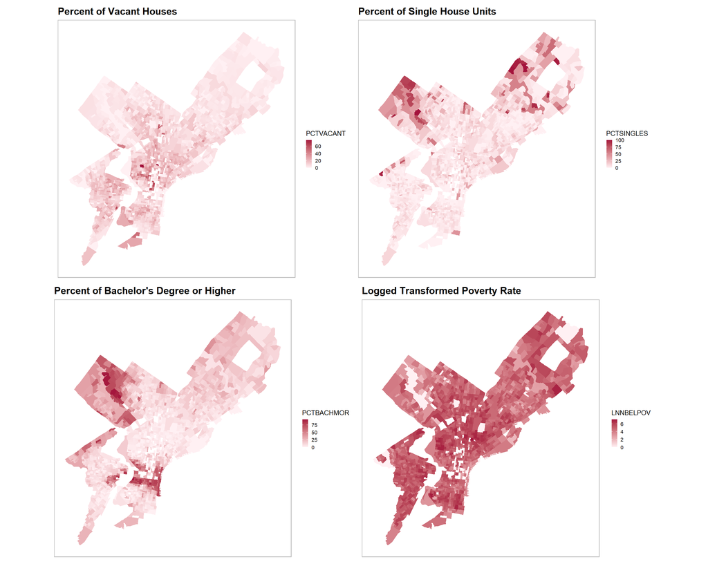

```r
shpe_longer<- shape %>%
  pivot_longer(cols = c("PCTVACANT", "PCTSINGLES", "PCTBACHMOR", "LNNBELPOV"),
               names_to = "Variable",
               values_to = "Value")
custom_titles <- c(
  PCTVACANT   = "Percent of Vacant Houses",
  PCTSINGLES  = "Percent of Single House Units",
  PCTBACHMOR  = "Percent of Bachelor's Degree or Higher",
  LNNBELPOV   = "Logged Transformed Poverty Rate"
)



plot_list <- lapply(unique(shpe_longer$Variable), function(var_name) {
  data_subset <- subset(shpe_longer, Variable == var_name)

  ggplot(data_subset) +
    geom_sf(aes(fill = Value), color = "transparent") +
    scale_fill_gradientn(
      colors = c("#fff0f3", "#a4133c"),
      name = var_name,
      na.value = "transparent"
    ) +
    labs(title = custom_titles[[var_name]]) +
    theme(
      legend.text = element_text(size = 8),
      legend.title = element_text(size = 10),
      legend.key.size = unit(0.3, "cm"),
      axis.text.x = element_blank(),
      axis.ticks.x = element_blank(),
      axis.text.y = element_blank(),
      axis.ticks.y = element_blank(),
      plot.subtitle = element_text(size = 9, face = "italic"),
      plot.title = element_text(size = 15, face = "bold"),
      panel.background = element_blank(),
      panel.border = element_rect(colour = "grey", fill = NA, size = 0.8)
    )
})

# Combine the plots into a grid (2 columns by 2 rows)
combined_plot <- (plot_list[[1]] + plot_list[[2]]) /
                 (plot_list[[3]] + plot_list[[4]])

combined_plot
```

These maps also help identify whether predictors are closely related to each other, which could cause **multicollinearity** problems. The **Percent of Bachelor’s Degree or Higher**(`PCTBACHMOR`) map looks very similar to the **Log Transformed Median House Value**(`LNMEDHVAL`) map, suggesting that areas with more college graduates tend to have higher house values. Also, the **Percent of Vacant Houses**(`PCTVACANT`) and **Percent of Single House Units**(`PCTSINGLES`) maps share a similar pattern—North Philadelphia and University City have a high percentage of vacant houses and a low percentage of single-house units, while Germantown/Chestnut Hill and Far Northeast Philadelphia show the opposite trend. This suggests that these two predictors may be strongly related, which could lead to multicollinearity issues in the regression analysis.

### Examining Multicollinearity & Correlation Matrix

To further examine multicollinearity, we create a correlation matrix between predictors. *All correlation values are below 0.7, indicating that no severe multicollinearity occurs in our model.*

```r
custom_labels <- c(
  "% of Individuals with Bachelor’s Degrees or Higher" = "PCTBACHMOR",
  "% of Vacant Houses" = "PCTVACANT",
  "% of Single House Units" = "PCTSINGLES",
  "# Households Living in Poverty" = "LNNBELPOV100"
)

predictor_vars <- data[, c("PCTVACANT", "PCTSINGLES", "PCTBACHMOR", "LNNBELPOV100")]

cor_matrix <- cor(predictor_vars, use = "complete.obs", method = "pearson")

print(cor_matrix)
```

```
##               PCTVACANT PCTSINGLES PCTBACHMOR LNNBELPOV100
## PCTVACANT     1.0000000 -0.1513734 -0.2983580    0.2495470
## PCTSINGLES   -0.1513734  1.0000000  0.1975461   -0.2905159
## PCTBACHMOR   -0.2983580  0.1975461  1.0000000   -0.3197668
## LNNBELPOV100  0.2495470 -0.2905159 -0.3197668    1.0000000
```

[figure not shown]

```r
rownames(cor_matrix) <- names(custom_labels)
colnames(cor_matrix) <- names(custom_labels)


ggcorrplot(cor_matrix,
           method = "square",
           type = "lower",
           lab = TRUE,
           lab_size = 3,
           colors = c("#a4133c", "white", "#a4133c"))+
    labs(title = "Correlation Matrix for all Predictor Variables") +
    theme(plot.subtitle = element_text(size = 9, face = "italic"),
        plot.title = element_text(size = 12, face = "bold"),
        axis.text.x = element_text(size = 7),
        axis.text.y = element_text(size = 7),
        axis.title = element_text(size = 8))
```

## Regression Results

### Parameter Estimations

Four independent variables were included in the multiple regression model to predict the log-transformed median house value (`LNMEDHVAL`) in Philadelphia at census block group level, including the proportion of vacant housing units (`PCTVACANT`), the proportion of single-family housing units (`PCTSINGLES`), the proportion of residents with a bachelor’s degree or higher (`PCTBACHMOR`), and the number of households living below the poverty line (`LNNBELPOV100`). The regression results are presented below:

```r
fit <- lm(LNMEDHVAL ~ PCTVACANT + PCTSINGLES + PCTBACHMOR + LNNBELPOV100, data=data)
summary(fit)
```

```
##
## Call:
## lm(formula = LNMEDHVAL ~ PCTVACANT + PCTSINGLES + PCTBACHMOR +
##     LNNBELPOV100, data = data)
##
## Residuals:
##      Min       1Q   Median       3Q      Max
## -2.25825 -0.20391  0.03822  0.21744  2.24347
##
## Coefficients:
##                Estimate Std. Error t value Pr(>|t|)
## (Intercept)  11.1137661  0.0465330 238.836  < 2e-16 ***
## PCTVACANT    -0.0191569  0.0009779 -19.590  < 2e-16 ***
## PCTSINGLES    0.0029769  0.0007032   4.234 2.42e-05 ***
## PCTBACHMOR    0.0209098  0.0005432  38.494  < 2e-16 ***
## LNNBELPOV100 -0.0789054  0.0084569  -9.330  < 2e-16 ***
## ---
## Signif. codes:  0 '***' 0.001 '**' 0.01 '*' 0.05 '.' 0.1 ' ' 1
##
## Residual standard error: 0.3665 on 1715 degrees of freedom
## Multiple R-squared:  0.6623, Adjusted R-squared:  0.6615
## F-statistic: 840.9 on 4 and 1715 DF,  p-value: < 2.2e-16
```

The regression output tells us that the median housing values are highly significant correlated with the proportion of vacant housing units(`PCTVANT`), the proportion of single-family housing units(`PCTSINGLES`), the proportion of residents with a bachelor’s degree or higher (`PCTBACHMOR`), and the log-transformed number of households living below the poverty line (`LNNBELPOV`), with $p-value<0.0001$ for all four predictors.

As the proportions of vacant housing units (`PCTVANT`) goes up by 1 unit (1%), the median house value goes down by approximately 1.915%, with holding all other three predictors constant. In addition, the respective $p-value$ for $\beta_1$ is less than 0.0001, indicating that if there is no relationship between `PCTVANT` and the dependent variable (i.e., if the null hypothesis that $\beta_1 = 0$ is true), then the probability of getting a $\beta_1$ coefficient estimate of -0.0191569 is less than 0.0001. We can safely reject the null hypothesis $H_0: \beta_1 = 0$ for $H_a: \beta_1 \neq 0$.

$$(e^{\beta} - 1) \times 100\% =
(e^{-0.0191569} - 1) \times 100\% \approx -1.915\%$$

Similarly, as the proportion of single-family housing units (`PCTSINGLES`) goes up by 1 unit (1%), the median house value goes up by approximately 0.298%, with holding all other three predictors constant. The $p-value$ for $\beta_2$ is less than 0.0001, indicating that if there is no relationship between `PCTSINGLES` and the dependent variable (i.e., if the null hypothesis that $\beta_2 = 0$ is true), then the probability of getting a $\beta_2$ coefficient estimate of 0.0029769 is less than 0.0001. We can also safely reject the null hypothesis $H_0: \beta_2 = 0$ for $H_a: \beta_2 \neq 0$.

Furthermore, as the proportion of residents with a bachelor’s degree or higher (`PCTBACHMOR`) goes up by 1 unit (1%), the median house value goes up by approximately 2.09%, with holding all other three predictors constant. Similar to $\beta_2$, the $p-value$ for $\beta_3$ is less than 0.0001, indicating that if there is no relationship between `PCTBACHMOR` and the dependent variable (i.e., if the null hypothesis that $\beta_3 = 0$ is true, then the probability of getting a $\beta_3$ coefficient estimate of 0.0209098 is less than 0.0001. We can also safely reject the null hypothesis $H_0: \beta_3 = 0$ for $H_a: \beta_3 \neq 0$.

$$(e^{\beta} - 1) \times 100\% =
(e^{0.0209098} - 1) \times 100\% \approx 2.09\%$$

Lastly, as 1 percent increase in the number of households living below the poverty line, the median house value goes down by approximately 0.078% , with holding all other three predictors constant. The $p-value$ for $\beta_4$ is also less than 0.0001 indicating that if there is no relationship between number of households below poverty line and the dependent variable (i.e., if the null hypothesis that $\beta_4 = 0$ is true), then the probability of getting a $\beta_4$ coefficient estimate of -0.0789054 is less than 0.0001. As stated before, we can also safely reject the null hypothesis $H_0: \beta_4 = 0$ for $H_a: \beta_4 \neq 0$.

$$(1.01^{\beta} - 1) \times 100\% =
(1.01^{-0.0789054} - 1) \times 100\% \approx -0.078\%$$

### Model Fit

```r
fit <- lm(LNMEDHVAL ~ PCTVACANT + PCTSINGLES + PCTBACHMOR + LNNBELPOV100, data=data)
summary(fit)
```

```
##
## Call:
## lm(formula = LNMEDHVAL ~ PCTVACANT + PCTSINGLES + PCTBACHMOR +
##     LNNBELPOV100, data = data)
##
## Residuals:
##      Min       1Q   Median       3Q      Max
## -2.25825 -0.20391  0.03822  0.21744  2.24347
##
## Coefficients:
##                Estimate Std. Error t value Pr(>|t|)
## (Intercept)  11.1137661  0.0465330 238.836  < 2e-16 ***
## PCTVACANT    -0.0191569  0.0009779 -19.590  < 2e-16 ***
## PCTSINGLES    0.0029769  0.0007032   4.234 2.42e-05 ***
## PCTBACHMOR    0.0209098  0.0005432  38.494  < 2e-16 ***
## LNNBELPOV100 -0.0789054  0.0084569  -9.330  < 2e-16 ***
## ---
## Signif. codes:  0 '***' 0.001 '**' 0.01 '*' 0.05 '.' 0.1 ' ' 1
##
## Residual standard error: 0.3665 on 1715 degrees of freedom
## Multiple R-squared:  0.6623, Adjusted R-squared:  0.6615
## F-statistic: 840.9 on 4 and 1715 DF,  p-value: < 2.2e-16
```

First, the residuals from the model show a reasonable distribution of errors, with a median residual of 0.03822, a minimum value of -2.26, a first quartile of -0.20, and a third quartile of 0.22, and a maximum value of 2.24. This distribution shows that the model captures the variability in the dependent variable well (logged transformed median home value), although some of the residuals are larger than 2.5 standard deviations from the mean, which are the outliers.

```r
anova_table <- anova(fit)
anova_table
```

```
## Analysis of Variance Table
##
## Response: LNMEDHVAL
##                Df  Sum Sq Mean Sq  F value    Pr(>F)
## PCTVACANT       1 180.392 180.392 1343.087 < 2.2e-16 ***
## PCTSINGLES      1  24.543  24.543  182.734 < 2.2e-16 ***
## PCTBACHMOR      1 235.118 235.118 1750.551 < 2.2e-16 ***
## LNNBELPOV100    1  11.692  11.692   87.054 < 2.2e-16 ***
## Residuals    1715 230.344   0.134
## ---
## Signif. codes:  0 '***' 0.001 '**' 0.01 '*' 0.05 '.' 0.1 ' ' 1
```

**The Analysis of Variance (ANOVA)** table shows additional insight into the significance of each predictor in explaining the variation in the dependent variable (`LNVMEDHVAL`). For proportion of vacant housing units (`PCTVACANT`), the sum of squares is 180.392, indicating that those amount of variation in `LNVMEDHVAL` that can be attributed to changes in `PCTVACANT`. A higher sum of squares indicates a mhigher relationship between the predictor and the dependent variable. The sum of squares for the percentage of residents with a bachelor’s degree or higher (`PCTBACHMOR`) explains the highest portion of the variance in `LNVMEDHVAL`. In contrast, the sum of squares for the log-transformed number of households living below the poverty line (`LNNBELPOV100`) explains the least amount of variance in `LNVMEDHVAL`, with only 11.69.

## Regression Assumptions Check

In this section, we conducted variety of analysis to check if the assumption of the linear regression were met. In the earlier section, we already checked the variable distribution and multicollinearity. Here, we will check following assumption:

- Linearity
- Normality of Residuals
- Homoscedasticity
- Independence of Observations without space autocorrelation
- Independence of Residuals without space autocorrelation

### Linearity

To further examine the linear relationship between the dependent variable and the predictors, we create four scatter plots, where the **x-axis** represents each predictor and the **y-axis** represents the dependent variable, **Log Transformed Median House Value**.

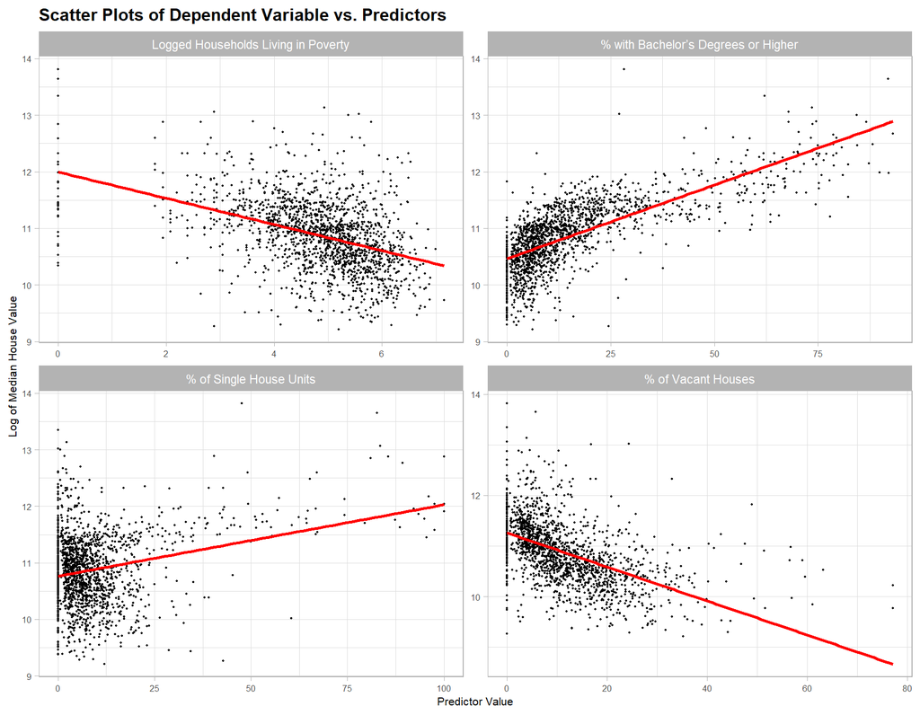

```r
longer<-data %>%
  pivot_longer(cols = c("PCTBACHMOR", "LNNBELPOV100", "PCTVACANT", "PCTSINGLES"),
               names_to = "Variable",
               values_to = "Value")

ggplot(longer,aes(x = Value, y = LNMEDHVAL)) +
  geom_point(color = "black", size= 0.4) +
  geom_smooth(method = "lm", color = "red", se = FALSE) +
  facet_wrap(~ Variable, scales = "free", labeller = as_labeller(c(
    "PCTBACHMOR" = "% with Bachelor’s Degrees or Higher",
    "LNNBELPOV100" = "Logged Households Living in Poverty",
    "PCTVACANT" = "% of Vacant Houses",
    "PCTSINGLES" = "% of Single House Units"
  )))  +
  theme_light() +
  theme(plot.subtitle = element_text(size = 9,face = "italic"),
        plot.title = element_text(size = 12, face = "bold"),
        axis.text.x=element_text(size=6),
        axis.text.y=element_text(size=6),
        axis.title=element_text(size=8)) +
  labs(title = "Scatter Plots of Dependent Variable vs. Predictors",
       x = "Predictor Value",
       y = "Log of Median House Value")
```

In summary, the scatterplot shows that while the (`PCTBACHMOR`) and (`LNMEDHVAL`) have a clear linear relationship, the other predictors have more complex non-linear relationships with the dependent variable. This suggests that the linear regression model may not fully capture the complexity of the relationships between the predictors and median house values.

### Normality of Residuals

Next, we examine the normality of residuals of the regression model. The histogram of standardized residuals provides a detail view of the of the distribution of the residuals from the OLS model, showing below:

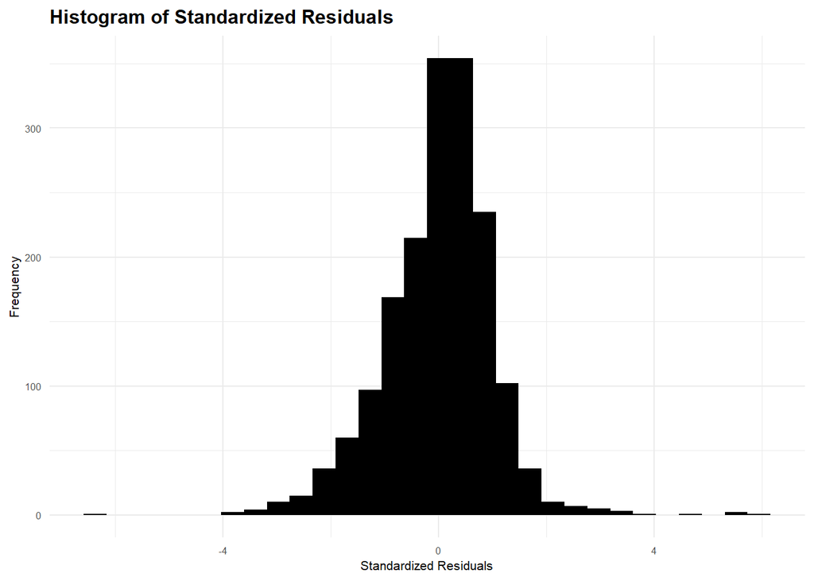

```r
ggplot(data, aes(x = Standardized_Residuals)) +
  geom_histogram(bins = 30, fill = "black") +
  labs(title = "Histogram of Standardized Residuals",
       x = "Standardized Residuals",
       y = "Frequency") +
  theme_minimal() +
  theme(plot.subtitle = element_text(size = 9,face = "italic"),
        plot.title = element_text(size = 12, face = "bold"),
        axis.text.x=element_text(size=6),
        axis.text.y=element_text(size=6),
        axis.title=element_text(size=8))
```

This graph indicate a general normal distribution of the residuals, with a bell shape curve centered around 0. The majority of the residuals are concentrated between -2 and 2 on the x-axis, with the highest frequency around 0. This concentration suggests that most of the predicted values are close to the actual values, leading to residuals that are small and symmetrically distributed around 0. **This generally met the assumption of the normality of residuals in OLS regression.**

However, there are still some noticeable deviations from perfect normality at the tails of the distribution. On the left side, there are few residuals with values smaller than -3, and on the right side, there are few residuals with values larger than 3. These outliers indicate that the model may not be capturing all the variability in the dependent variable, leading to some large residuals. While the majority of the residuals are normally distributed, these outliers suggest that the model may not be fully capturing the complexity of the relationship between the predictors and the dependent variable. Further examination of those specific data points may be necessary to understand the reasons for these large residuals.

### Homoscedasticity

After checking the normality of residuals, we examine the homoscedasticity, which requires that the residuals have constant variance across all levels of the fitted values. The standard is the residuals divided by their standard error.
$$e_i^* \approx \frac{\epsilon_i}{s} \approx
\frac{\epsilon_i}{\sqrt{\frac{SSE}{n-2}}}$$
The scatter plot of standardized residuals against fitted values is a valuable tool for assessing homoscedasticity:

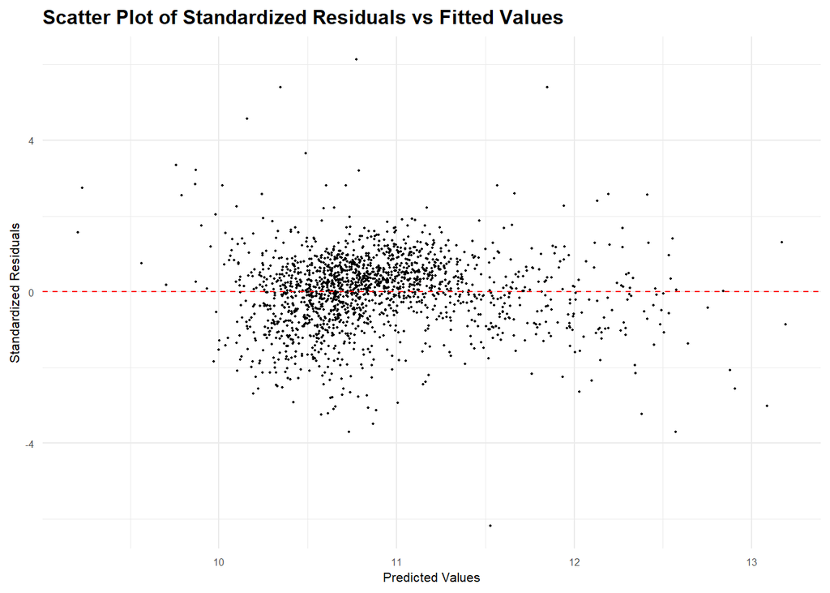

```r
ggplot(data, aes(x = Fitted, y = Standardized_Residuals)) +
  geom_point(color = "black", size= 0.4) +
  geom_hline(yintercept = 0, linetype = "dashed", color = "red") +
  labs(
    title = "Scatter Plot of Standardized Residuals vs Fitted Values",
    x = "Predicted Values",
    y = "Standardized Residuals"
  ) +
  theme_minimal() +
  theme(plot.subtitle = element_text(size = 9,face = "italic"),
        plot.title = element_text(size = 12, face = "bold"),
        axis.text.x=element_text(size=6),
        axis.text.y=element_text(size=6),
        axis.title=element_text(size=8))
```

The scatterplot shows **no clear pattern in the residuals**, as the predicted values rising or falling. Instead, they seem to be pretty randomly distributed around the 0 line, indicating that the residuals have constant variance across all levels of the fitted values.There is no obvious funnel shape or systematic variation trend suggests that the assumption of homoscedasticity is satisfied. In addition, the residuals are generally symmetrical distributed around the 0 line,which indicate the model does not systemically over- or under-predicted the dependent variable over the range of fitted values.

However, the plot does show some potential outliers, particularly those points are outside -3 and 3 standardized residuals. These extreme residuals are located upper or lower of the main residual clusters and may indicate that the model’s predicted values deviate significantly from the actual values. Although the number of residuals is relative small, their presence indicates that the model may not fit all data well.

### Independence of Observations

Then, we test the independence of observations, specifically examining spatial autocorrelation. The choropleth map of the Percentage of **Percent of Bachelor’s Degree or Higher** shows that central city areas and Germantown/Chestnut Hill have higher median house values, while North Philadelphia has lower values. This clustering suggests potential spatial dependence among block groups. Similarly, the dependent variable, **Log Transformed Median House Value**, follows the same pattern, further indicating that observations may not be spatially independent.

### Independence of Residuals

The final assumption we test is the independence of residuals, which we assess by analyzing the choropleth map of regression residuals. The map reveals that residuals tend to be systematically low in the center of Philadelphia and higher in surrounding block groups, suggesting spatial autocorrelation. **This pattern indicates that residuals are not randomly distributed, meaning the current regression model may not fully capture spatial heterogeneity.** As a result, further examination of spatial autocorrelation in both the variables and residuals is necessary, and a spatial regression model may be required.

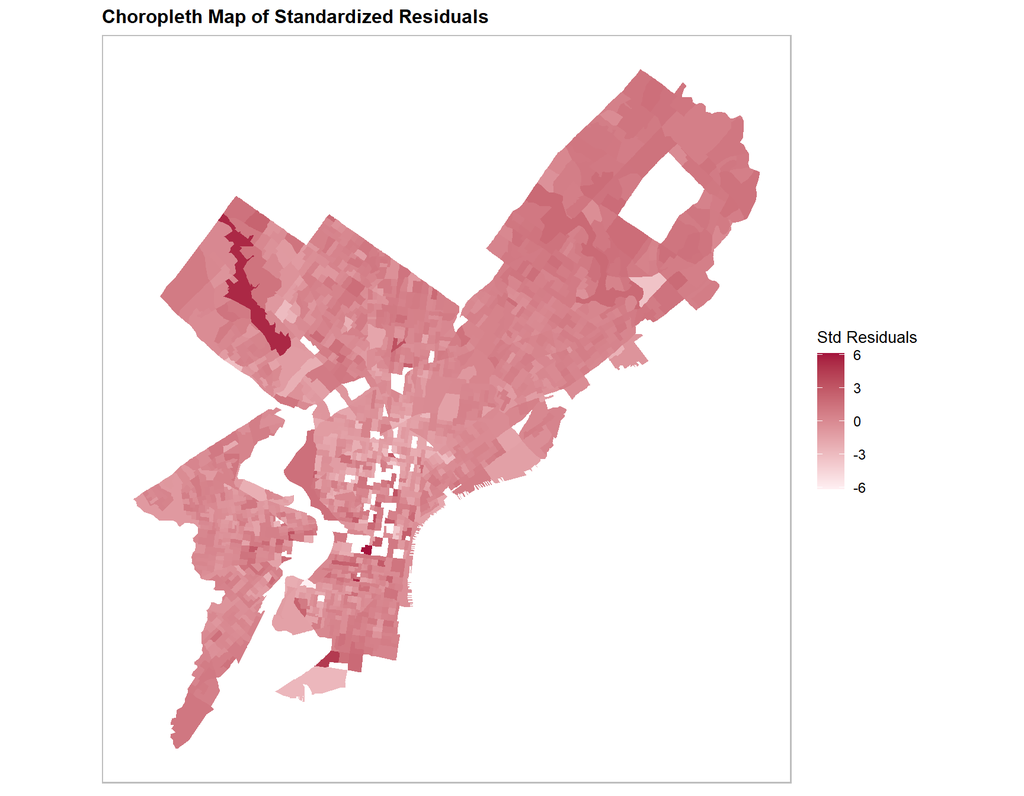

```r
join<- data %>%
  dplyr::select(POLY_ID, Standardized_Residuals)

shape <- shape %>%
  left_join(join, by = c("POLY_ID" = "POLY_ID"))

ggplot(shape)+
  geom_sf(aes(fill = Standardized_Residuals), color = "transparent") +
  scale_fill_gradientn(colors = c("#fff0f3", "#a4133c"),
                       name = "Std Residuals",
                       na.value = "transparent") +  # Choose a color palette, invert direction if needed
  labs(title = "Choropleth Map of Standardized Residuals") +
  theme(legend.text = element_text(size = 9),
        legend.title = element_text(size = 10),
        axis.text.x = element_blank(),
        axis.ticks.x = element_blank(),
        axis.text.y = element_blank(),
        axis.ticks.y = element_blank(),
        plot.subtitle = element_text(size = 9, face = "italic"),
        plot.title = element_text(size = 12, face = "bold"),
        panel.background = element_blank(),
        panel.border = element_rect(colour = "grey", fill = NA, size = 0.8))
```

## Additional Analysis

### Stepwise Regression

We performed stepwise regression to determine the most relevant predictors for the model. The initial model included all four predictors, with a residual sum of squares of 230.34 and an Akaikie Information Criterion (AIC) of -3448.07. A lower AIC value indicates a better balance between model fit and complexity.

```r
stepwise_model <-  stepAIC(fit, direction = "both")
```

```
## Start:  AIC=-3448.07
## LNMEDHVAL ~ PCTVACANT + PCTSINGLES + PCTBACHMOR + LNNBELPOV100
##
##                Df Sum of Sq    RSS     AIC
## <none>                      230.34 -3448.1
## - PCTSINGLES    1     2.407 232.75 -3432.2
## - LNNBELPOV100  1    11.692 242.04 -3364.9
## - PCTVACANT     1    51.546 281.89 -3102.7
## - PCTBACHMOR    1   199.020 429.36 -2379.0
```

The stepwise process examined whether removing each predictor would reduce the AIC and improve the model fit. However, removing any predictors resulted in a higher AIC and increased in residual sum of squares(RSS), indicating that all four predictors are important for the model. For instance, reducing the proportion of vacant housing units (`PCTVACANT`) from the model increased the AIC to -3102.7 and increase the residual sum of squares to 281.89, indicating a severe decline in model performance.

As a result, non of the predictors were removed from the model, as eliminating any of them worsened the performance. Therefore, the final model remained unchanged from the initial one which include all four predictors.

```r
stepwise_model$anova
```

```
## Stepwise Model Path
## Analysis of Deviance Table
##
## Initial Model:
## LNMEDHVAL ~ PCTVACANT + PCTSINGLES + PCTBACHMOR + LNNBELPOV100
##
## Final Model:
## LNMEDHVAL ~ PCTVACANT + PCTSINGLES + PCTBACHMOR + LNNBELPOV100
##
##
##   Step Df Deviance Resid. Df Resid. Dev       AIC
## 1                       1715   230.3435 -3448.073
```

### Cross-Validation

We also performed 5 fold cross-validation to access the model’s predictive power and determine hwether a model with fewer predictors could perform better.

```r
lm <-  trainControl(method = "cv", number = 5)

cvlm_model <- train(LNMEDHVAL ~ PCTVACANT + PCTSINGLES + PCTBACHMOR + LNNBELPOV100, data=data, method = "lm", trControl = lm)

print(cvlm_model)
```

```
## Linear Regression
##
## 1720 samples
##    4 predictor
##
## No pre-processing
## Resampling: Cross-Validated (5 fold)
## Summary of sample sizes: 1376, 1376, 1376, 1376, 1376
## Resampling results:
##
##   RMSE       Rsquared   MAE
##   0.3664021  0.6603461  0.2725127
##
## Tuning parameter 'intercept' was held constant at a value of TRUE
```

```r
cvlm_model_reduced = train(LNMEDHVAL ~ PCTVACANT + MEDHHINC, data = data, method = "lm", trControl = lm)

print(cvlm_model_reduced)
```

```
## Linear Regression
##
## 1720 samples
##    2 predictor
##
## No pre-processing
## Resampling: Cross-Validated (5 fold)
## Summary of sample sizes: 1376, 1376, 1376, 1376, 1376
## Resampling results:
##
##   RMSE       Rsquared   MAE
##   0.4422668  0.5053824  0.3176182
##
## Tuning parameter 'intercept' was held constant at a value of TRUE
```

# Discussion and Limitations

In this study, we analyzed Philadelphia census block group data (n = 1,720) to examine how neighborhood characteristics relate to median house values. To address non-normality, we applied a logarithmic transformation to the median house value, which allows us to interpret the regression coefficients as approximate percentage changes in the median house value. Our regression analysis revealed that for every 1-percentage point increase in the percentage of vacant houses (`PCTVACANT`), the median house value decreases by approximately 1.915%. Similarly, a 1-percentage point increase in the percentage of single-family homes (`PCTSINGLES`) is associated with a roughly 0.298% increase in the median house value, while a 1-percentage point increase in the percentage of residents with at least a bachelor’s degree (`PCTBACHMOR`) corresponds to about a 2.09% increase. In contrast, every 1-percentage point increase in the log-transformed number of households living below the poverty line (`LNNBELPOV100`) is linked with approximately a 0.078% decrease in the median house value. Overall, our model explains about 66% of the variation in the dependent variable, indicating that the selected predictors significantly influence median house values. While most results were in line with expectations, the relatively small impact of the percentage of single-family homes (`PCTSINGLES`) was somewhat surprising.

### Model Quality and Additional Analyses

The model’s overall quality is supported by an R² of approximately 0.66 and a highly significant F-ratio, indicating a strong overall fit. Stepwise regression, guided by the Akaike Information Criterion, retained all four predictors (`PCTVACANT`, `PCTSINGLES`, `PCTBACHMOR`, and `LNNBELPOV100`), demonstrating that each variable contributes meaningfully to explaining the variation in the median house value.

Furthermore, 5-fold cross-validation, evaluated using root mean square error (RMSE), showed that the full model performs better than a reduced model that includes only the percentage of vacant houses (`PCTVACANT`) and median household income(`MEDHHINC`). These validation techniques reinforce our confidence in the robustness and predictive power of our model.

### Limitations of the Model

Despite the robust performance of our model, several limitations should be noted:

- **Spatial Autocorrelation:** Choropleth maps indicate that median house values and some predictors display spatial clustering. This suggests that neighboring census block groups may influence one another, potentially biasing our parameter estimates. Future research should incorporate spatial econometric techniques, such as Moran’s I or spatial lag models, to address this issue.
- **Measurement of Poverty:** The variable representing households living below the poverty line (`LNNBELPOV100`) is used as a raw count rather than as a percentage. This choice may obscure relative differences in poverty levels across block groups and affect the interpretation of its impact on median house values.
- **Zero-Inflated Distributions:** Although the logarithmic transformation improved the normality of most variables, it may not fully address the zero-inflated nature of some predictors. Future studies could explore alternative transformation methods or models that are better suited for handling zero-heavy distributions.

### Possibility of Ridge or LASSO Regression

Ridge and LASSO regression are used when there are highly correlated predictors or when only a subset of features is expected to be truly important. In such cases, some predictor coefficients may become excessively large, leading to overfitting in a linear model. These methods manage overfitting by adding a penalty term to the loss function, which constrains the coefficients. However, in our model, the highest correlation between predictors is 0.32, indicating no significant multicollinearity. Additionally, no predictor exhibits excessively large coefficients. Therefore, applying Ridge or LASSO regression in this case would be unnecessary.

### Future Research and Policy Implications

Our findings have significant implications for urban policy aimed at promoting community stability and equitable growth. The strong negative effect of higher vacancy rates (`PCTVACANT`) on median house values suggests that policies focused on rehabilitating vacant properties or supporting community-based investments could help stabilize neighborhoods without displacing existing residents. Similarly, the positive association between educational attainment (`PCTBACHMOR`) and median house values highlights the importance of policies that enhance educational opportunities while also ensuring affordable housing for long-term residents. Future research should consider incorporating additional predictors, such as access to public amenities, quality of local services, or historical neighborhood trends, and should employ spatial econometric techniques to capture spatial dependencies more accurately. Although our current analysis does not warrant the use of Ridge or LASSO regression, these methods might be revisited in future studies if the dataset expands or if additional predictors are included.